# Introducción a R

Teresa Ortiz, Alicia Mastretta

Febrero 2015

Este es el primer de 2 juegos de notas introductorias a R, con un enfoque en análisis de datos. A diferencia de otros recursos, no se pretende dar una introducción general a R sino mostrar las herramientas más importantes para comenzar a utilizar R en análisis de datos. En este primer juego se cubren la introducción a R y la sección de visualización. Más adelante aprenderemos a usar R para manipulación de datos y modelación. Las notas están ordenadas como sigue:

- El ambiente y el lenguaje R
- Intorducción a R para análisis de datos: paquetes, vectores y data frames
- Datos faltantes
- Lectura de datos y guardar datos
- Visualización: gráficas con ggplot2

## El ambiente y el lenguaje R

##### ¿Qué es R?

- R es un lenguaje de programación y un ambiente de cómputo estadístico
- R es software libre (no dice qué puedes o no hacer con el software), de código abierto (todo el código de R se puede inspeccionar - y se inspecciona).
- Cuando instalamos R, instala la base de R. Mucha de la funcionalidad adicional está en **paquetes** que la comunidad contribuye.

##### ¿Cómo entender R?

- Hay una sesión de R corriendo. La consola de R es la interfaz entre R y nosotros.
- En la sesión hay objetos. Todo en R es un objeto: vectores, tablas, funciones, etc.
- Operamos aplicando funciones a los objetos y creando nuevos objetos.

##### ¿Por qué R?

- R funciona en casi todas las plataformas (Mac, Windows, Linux e incluso en Playstation 3).
- R es un lenguaje de programación completo, permite desarrollo de DSLs.
- R promueve la investigación reproducible.
- R está actualizado gracias a que tiene una activa comunidad. Solo en CRAN hay cerca de 8000 paquetes (funcionalidad adicional de R creadas creada por la comunidad).
- R se puede combinar con otras herramientas.
- R tiene capacidades gráficas muy sofisticadas.
- R es popular ([la guerra del software](http://datacamp.wpengine.com/wp-content/uploads/2014/05/infograph.png)).

### Descargar R y RStudio

Para comenzar se debe descargar [R](https://cran.r-project.org), esta descarga incluye R básico y un editor de textos para escribir código. Después de descargar R se recomienda descargar [RStudio](https://www.rstudio.com/products/rstudio/download/) (gratis y libre).

RStudio es un ambiente de desarrollo integrado para R: incluye una consola, un editor de texto y un conjunto de herramientas para administrar el espacio de trabajo cuando se utiliza R.

Algunos *shortcuts* útiles en RStudio som:

**En el editor**

- command/ctrl + enter: enviar código a la consola
- ctrl + 2: mover el cursor a la consola

**En la consola**

- flecha hacia arriba: recuperar comandos pasados
- ctrl + flecha hacia arriba: búsqueda en los comandos
- ctrl + 1: mover el cursor al editor

## Introducción

La mejor manera de usar R para análisis de datos es aprovechando la gran cantidad de paquetes que aportan funcionalidad adicional. Desde Rstudio podemos instalar paquetes (Tools - > Install packages o usar la función `install.packages("nombre_paquete")`). Una vez instalados, podemos cargarlos a nuestra sesión de R mediante `library`. Por ejemplo, para cargar el paquete `readr` hacemos:

```r
# print(read_csv)
# Error in print(read_csv) : object 'read_csv' not found

library(readr)
print(read_csv)
```

```
## function (file, col_names = TRUE, col_types = NULL, na = "NA",
##     skip = 0, n_max = -1, progress = interactive())
## {
##     tokenizer <- tokenizer_csv(na = na)
##     read_delimited(file, tokenizer, col_names = col_names, col_types = col_types,
##         skip = skip, n_max = n_max, progress = progress)
## }
## <environment: namespace:readr>
```

`read_csv` es una función que aporta el paquete `readr`.

El paquete readr se debe instalar una sola vez, sin embargo, se debe cargar (ejecutar `library(readr)`) en cada sesión de R que lo ocupemos.

Los paquetes básicos que necesitaremos para análisis de datos son (en este juego de notas solo usaremos dplyr, readr y ggplot2):

1. `readr` y `readxl` para leer datos
2. `tidyr` manipulación de datos
3. `lubridate` para manejar fechas
4. `dplyr` filtros, cálculos y agregación de datos.
5. `ggplot2` graficar

```r
library(lubridate)
library(ggplot2)
library(readr)
library(tidyr)
library(dplyr)
```

### Estructuras de datos

En R se puede trabajar con distintas estructuras de datos, algunas son de una sola dimensión y otras permiten más, como indica el diagrama de abajo:

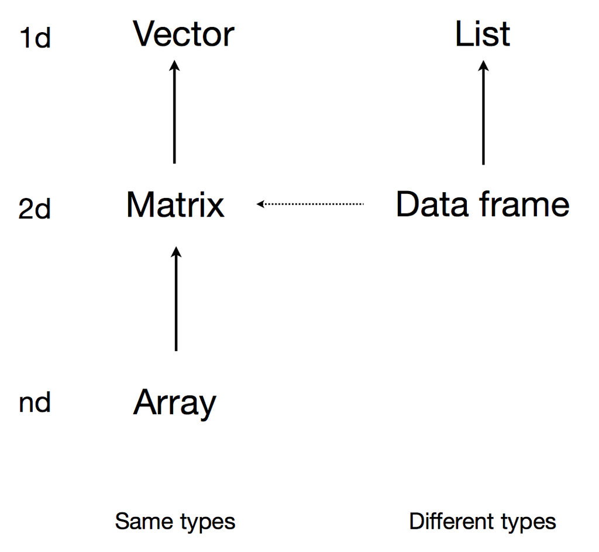

nosotros trabajaremos principalmente con *vectores* y *data frames*.

### Vectores y *data frames*

Comenzamos viendo algunas operaciones básicas con vectores.

```r
a <- c(5, 2, 4.1, 7, 9.2)
a
```

```
## [1] 5.0 2.0 4.1 7.0 9.2
```

```r
a[1]
```

```
## [1] 5
```

```r
a[2]
```

```
## [1] 2
```

```r
a[2:4]
```

```
## [1] 2.0 4.1 7.0
```

Las operaciones básicas con vectores son componente a componente:

```r
b <- a + 10
b
```

```
## [1] 15.0 12.0 14.1 17.0 19.2
```

```r
d <- sqrt(a)
d
```

```
## [1] 2.236068 1.414214 2.024846 2.645751 3.033150
```

```r
a + d
```

```
## [1]  7.236068  3.414214  6.124846  9.645751 12.233150
```

```r
10 * a
```

```
## [1] 50 20 41 70 92
```

```r
a * d
```

```
## [1] 11.180340  2.828427  8.301867 18.520259 27.904982
```

Y podemos crear secuencias como sigue:

```r
ejemplo_1 <- 1:10
ejemplo_1
```

```
##  [1]  1  2  3  4  5  6  7  8  9 10
```

```r
ejemplo_2 <- seq(0, 1, 0.25)
ejemplo_2
```

```
## [1] 0.00 0.25 0.50 0.75 1.00
```

Para calcular características de vectores usamos funciones:

```r
# media del vector
mean(a)
```

```
## [1] 5.46
```

```r
# suma de sus componentes
sum(a)
```

```
## [1] 27.3
```

```r
# longitud del vector
length(a)
```

```
## [1] 5
```

También podemos construir vectores de caracteres:

```r
frutas <- c('manzana', 'manzana', 'pera', 'plátano', 'fresa')
frutas
```

```
## [1] "manzana" "manzana" "pera"    "plátano" "fresa"
```

Podemos juntar vectores del mismo tamaño en tablas, que se llaman `data.frame`. Por ejemplo:

```r
tabla <- data_frame(n = 1:5, valor = a, fruta = frutas) # la función data_frame de dplyr es más conveniente que data.frame de R base.
tabla
```

```
## Source: local data frame [5 x 3]
##
##       n valor   fruta
##   (int) (dbl)   (chr)
## 1     1   5.0 manzana
## 2     2   2.0 manzana
## 3     3   4.1    pera
## 4     4   7.0 plátano
## 5     5   9.2   fresa
```

Los data frames son estructuras rectangulares donde cada columna es del mismo tipo (e.g. categórica o factor, numérica, caracter) pero columnas distintas pueden tener diferentes tipos.

```r
library(ggplot2)
head(diamonds)
```

```
##   carat       cut color clarity depth table price    x    y    z
## 1  0.23     Ideal     E     SI2  61.5    55   326 3.95 3.98 2.43
## 2  0.21   Premium     E     SI1  59.8    61   326 3.89 3.84 2.31
## 3  0.23      Good     E     VS1  56.9    65   327 4.05 4.07 2.31
## 4  0.29   Premium     I     VS2  62.4    58   334 4.20 4.23 2.63
## 5  0.31      Good     J     SI2  63.3    58   335 4.34 4.35 2.75
## 6  0.24 Very Good     J    VVS2  62.8    57   336 3.94 3.96 2.48
```

La instrucción `str` nos describe el tipo de variables en el data.frame:

```r
str(diamonds)
```

```
## 'data.frame':    53940 obs. of  10 variables:
##  $ carat  : num  0.23 0.21 0.23 0.29 0.31 0.24 0.24 0.26 0.22 0.23 ...
##  $ cut    : Ord.factor w/ 5 levels "Fair"<"Good"<..: 5 4 2 4 2 3 3 3 1 3 ...
##  $ color  : Ord.factor w/ 7 levels "D"<"E"<"F"<"G"<..: 2 2 2 6 7 7 6 5 2 5 ...
##  $ clarity: Ord.factor w/ 8 levels "I1"<"SI2"<"SI1"<..: 2 3 5 4 2 6 7 3 4 5 ...
##  $ depth  : num  61.5 59.8 56.9 62.4 63.3 62.8 62.3 61.9 65.1 59.4 ...
##  $ table  : num  55 61 65 58 58 57 57 55 61 61 ...
##  $ price  : int  326 326 327 334 335 336 336 337 337 338 ...
##  $ x      : num  3.95 3.89 4.05 4.2 4.34 3.94 3.95 4.07 3.87 4 ...
##  $ y      : num  3.98 3.84 4.07 4.23 4.35 3.96 3.98 4.11 3.78 4.05 ...
##  $ z      : num  2.43 2.31 2.31 2.63 2.75 2.48 2.47 2.53 2.49 2.39 ...
```

Para lograr una programación eficiente en R es importante conocer las técnicas de indexar data frames:

```r
# extraemos los primeros cinco renglones
diamonds[1:5, ]
```

```
##   carat     cut color clarity depth table price    x    y    z
## 1  0.23   Ideal     E     SI2  61.5    55   326 3.95 3.98 2.43
## 2  0.21 Premium     E     SI1  59.8    61   326 3.89 3.84 2.31
## 3  0.23    Good     E     VS1  56.9    65   327 4.05 4.07 2.31
## 4  0.29 Premium     I     VS2  62.4    58   334 4.20 4.23 2.63
## 5  0.31    Good     J     SI2  63.3    58   335 4.34 4.35 2.75
```

```r
# extraemos los primeros cinco renglones y las columnas 2,4,6
diamonds[1:5, c(2, 4, 6)]
```

```
##       cut clarity table
## 1   Ideal     SI2    55
## 2 Premium     SI1    61
## 3    Good     VS1    65
## 4 Premium     VS2    58
## 5    Good     SI2    58
```

```r
# también podemos extraer columnase usando $: extraemos la columna x
head(diamonds$x)
```

```
## [1] 3.95 3.89 4.05 4.20 4.34 3.94
```

```r
# ¿Que extraemos con las siguientes 2 instrucciones?
diamonds[diamonds$x == diamonds$y, ]
```

```
##       carat       cut color clarity depth table price    x    y    z
## 3398   0.30     Ideal     H    VVS2  62.5    54   567 4.30 4.30 2.70
## 10056  0.27 Very Good     F    VVS1  62.0    55   591 4.16 4.16 2.59
## 11964  1.00 Very Good     H     VS2  63.3    53  5139 0.00 0.00 0.00
## 15952  1.14      Fair     G     VS1  57.5    67  6381 0.00 0.00 0.00
## 16517  1.00   Premium     E     VS2  60.0    60  6600 6.43 6.43 3.89
## 16852  1.00   Premium     E     VS2  60.0    60  6720 6.43 6.43 3.89
## 17369  1.22   Premium     G     SI2  62.4    61  6969 6.79 6.79 4.23
## 24521  1.56     Ideal     G     VS2  62.2    54 12800 0.00 0.00 0.00
## 26244  1.20   Premium     D    VVS1  62.1    59 15686 0.00 0.00 0.00
## 27430  2.25   Premium     H     SI2  62.8    59 18034 0.00 0.00 0.00
## 34303  0.32     Ideal     D    VVS2  62.1    54   858 4.40 4.40 2.74
## 40017  0.42     Ideal     H    VVS1  62.8    57  1108 4.79 4.79 3.01
## 41856  0.61   Premium     G     SI1  60.8    60  1255 5.42 5.42 3.31
## 42128  0.48     Ideal     F     VS2  62.4    54  1279 5.03 5.03 3.15
## 43491  0.51   Premium     F     SI1  61.4    59  1421 5.13 5.13 3.16
## 49557  0.71      Good     F     SI2  64.1    60  2130 0.00 0.00 0.00
## 49558  0.71      Good     F     SI2  64.1    60  2130 0.00 0.00 0.00
```

```r
diamonds[-(1:53929), c("carat", "price")]
```

```
##       carat price
## 53930  0.71  2756
## 53931  0.71  2756
## 53932  0.71  2756
## 53933  0.70  2757
## 53934  0.70  2757
## 53935  0.72  2757
## 53936  0.72  2757
## 53937  0.72  2757
## 53938  0.70  2757
## 53939  0.86  2757
## 53940  0.75  2757
```

como vemos arriba para indexar los data frames tenemos que indicar filas y columnas, en el lado izquierdo de los corchetes se indica (con un vector) que filas queremos extraer, y en el lado derecho se indican las columnas: `diamonds[filas, columnas]`. También vale la pena notar que `diamonds$x` regresa la columna x como vector, es decir, `diamonds$x` es de una sola dimensión.

### Datos faltantes

En R los datos faltantes se expresan como `NA`, ¿qué regresan las siguientes expresiones?

```r
5 + NA
NA / 2
sum(c(5, 4, NA))
mean(c(5, 4,  NA))
NA < 3
NA == 3
NA == NA
```

Las expresiones anteriores regresan `NA`, el hecho que la media de un vector que incluye NAs o su suma regrese NAs se debe a que el default en R es propagar los valores faltantes, esto es, si deconozco el valor de una de las componentes de un vector, también desconozco la suma del mismo; sin embargo, muchas funciones tienen un argumento *na.rm* para removerlos,

```r
sum(c(5, 4, NA), na.rm = TRUE)
```

```
## [1] 9
```

```r
mean(c(5, 4, NA), na.rm = TRUE)
```

```
## [1] 4.5
```

El manejo de datos faltantes en R utiliza una lógica ternaria (como SQL):

```r
NA == NA
```

```
## [1] NA
```

La expresión anterior puede resultar confusa, una manera de pensar en esto es considerar los NA como *no sé*, por ejemplo si no se la edad de Juan y no se la edad de Esteban, la pregunta a ¿Juan tiene la misma edad que Esteban? es *no sé* (NA).

```r
edad_Juan <- NA
edad_Esteban <- NA
edad_Juan == edad_Esteban
```

```
## [1] NA
```

```r
edad_Jose <- 32
# Juan es menor que José?
edad_Juan < edad_Jose
```

```
## [1] NA
```

### Cargar datos

Hay muchas maneras de ingresar datos en R, un paquete muy conveniente es readr. Este se utiliza para leer archivos de texto, uno de los formatos más comunes de datos es *csv* (comma separated values), cualquier hoja de excel se puede extraer en este formato.

Cargamos el paquete (aunque no es necesario porque lo hicimos arriba) y leemos un archivo de nombres de bebés en EUA:

```r
library(readr)
bnames <- read_csv("data/bnames.csv")
bnames
```

```
## Source: local data frame [258,000 x 4]
##
##     year    name  percent   sex
##    (int)   (chr)    (dbl) (chr)
## 1   1880    John 0.081541   boy
## 2   1880 William 0.080511   boy
## 3   1880   James 0.050057   boy
## 4   1880 Charles 0.045167   boy
## 5   1880  George 0.043292   boy
## 6   1880   Frank 0.027380   boy
## 7   1880  Joseph 0.022229   boy
## 8   1880  Thomas 0.021401   boy
## 9   1880   Henry 0.020641   boy
## 10  1880  Robert 0.020404   boy
## ..   ...     ...      ...   ...
```

```r
str(bnames)
```

```
## Classes 'tbl_df', 'tbl' and 'data.frame':    258000 obs. of  4 variables:
##  $ year   : int  1880 1880 1880 1880 1880 1880 1880 1880 1880 1880 ...
##  $ name   : chr  "John" "William" "James" "Charles" ...
##  $ percent: num  0.0815 0.0805 0.0501 0.0452 0.0433 ...
##  $ sex    : chr  "boy" "boy" "boy" "boy" ...
```

La función `read_csv` tiene como argumento la ruta a la base de datos, esta puede ser absoluta o relativa. Para usar rutas relativas es necesario saber cual es nuestro directorio de trabajo, para esto ejecutamos:

```r
getwd()
```

```
## [1] "/Volumes/ARCHIVOS_C/Mac_Pro/r-conabio/01-introduccion"
```

También es posible leer bases de datos usando el url.

```r
# datos de abulón (sexo, longitud, diámetro, altura, peso, ...)
# Fuente https://archive.ics.uci.edu/ml/datasets/Abalone
abalone <- read_csv("https://archive.ics.uci.edu/ml/machine-learning-databases/abalone/abalone.data", col_names = FALSE)
str(abalone)
```

```
## Classes 'tbl_df', 'tbl' and 'data.frame':    4177 obs. of  9 variables:
##  $ X1: chr  "M" "M" "F" "M" ...
##  $ X2: num  0.455 0.35 0.53 0.44 0.33 0.425 0.53 0.545 0.475 0.55 ...
##  $ X3: num  0.365 0.265 0.42 0.365 0.255 0.3 0.415 0.425 0.37 0.44 ...
##  $ X4: num  0.095 0.09 0.135 0.125 0.08 0.095 0.15 0.125 0.125 0.15 ...
##  $ X5: num  0.514 0.226 0.677 0.516 0.205 ...
##  $ X6: num  0.2245 0.0995 0.2565 0.2155 0.0895 ...
##  $ X7: num  0.101 0.0485 0.1415 0.114 0.0395 ...
##  $ X8: num  0.15 0.07 0.21 0.155 0.055 0.12 0.33 0.26 0.165 0.32 ...
##  $ X9: int  15 7 9 10 7 8 20 16 9 19 ...
```

En caso de que se quieran leer hojas de excel se recomienda el paquete *readxl*.

```r
library(readxl)
conapo <- read_excel("data/conapo_2010.xls", sheet = "mun_carencias")
conapo
```

```
## Source: local data frame [2,456 x 10]
##
##      CVE analfabeta sin_primaria sin_drenaje sin_electricidad
##    (dbl)      (dbl)        (dbl)       (dbl)            (dbl)
## 1   1001       2.59        11.48        0.49             0.31
## 2   1002       5.54        26.02        5.72             2.14
## 3   1003       6.19        28.88        0.79             0.87
## 4   1004       4.35        21.81        2.18             2.00
## 5   1005       3.76        18.21        1.26             1.17
## 6   1006       4.11        18.74        0.94             0.98
## 7   1007       4.70        19.22        2.23             0.80
## 8   1008       3.45        18.93        6.33             1.85
## 9   1009       5.91        26.77        3.23             1.32
## 10  1010       5.77        25.67        6.22             3.03
## ..   ...        ...          ...         ...              ...
## Variables not shown: sin_agua_entubada (dbl), con_hacinamiento (dbl),
##   con_piso_tierra (dbl), habitantes_5000 (dbl), salarios_minimos (dbl)
```

Si se desea importar datos de SAS, SPSS o STATA consultar el paquete `haven`.

### Guardar datos y objectos

Podemos guardar un data frame en formato *csv* usando la instrucción write_csv.

```r
write_csv(conapo, path = "data/conapo.csv")
```

También podemos guardar *objetos* creados en R usando

```r
mi_vector <- c('uno','dos','tres')
save(mi_vector, file = 'vector_uno.RData')
rm('mi_vector')
load('vector_uno.RData')
mi_vector
```

```
## [1] "uno"  "dos"  "tres"
```

Nótese que se guarda el objeto con su nombre. Si quieres guardar solamente el objeto,

```r
saveRDS(mi_vector, file ='vector_dos.RData')
nuevo_vector <- readRDS(file = 'vector_dos.RData')
nuevo_vector
```

```
## [1] "uno"  "dos"  "tres"
```

## Visualización

Utilizaremos el paquete ggplot2 y cubriremos los siguientes puntos:

- Gráfica de dispersión
- Páneles
- Distintos tipos de gráficas

#### Gráficas de dispersión

```r
# install.packages("ggplot2") # sólo se hace una vez
library(ggplot2) # Cargamos el paquete en nuestra sesión
```

Usaremos el conjunto de datos *mpg* que se incluye en R, puedes encontrar información de esta base de datos tecleando `?mpg`.

```r
?mpg
# primeras líneas
head(mpg)
```

```
##   manufacturer model displ year cyl      trans drv cty hwy fl   class
## 1         audi    a4   1.8 1999   4   auto(l5)   f  18  29  p compact
## 2         audi    a4   1.8 1999   4 manual(m5)   f  21  29  p compact
## 3         audi    a4   2.0 2008   4 manual(m6)   f  20  31  p compact
## 4         audi    a4   2.0 2008   4   auto(av)   f  21  30  p compact
## 5         audi    a4   2.8 1999   6   auto(l5)   f  16  26  p compact
## 6         audi    a4   2.8 1999   6 manual(m5)   f  18  26  p compact
```

```r
# estructura de la base
str(mpg)
```

```
## 'data.frame':    234 obs. of  11 variables:
##  $ manufacturer: Factor w/ 15 levels "audi","chevrolet",..: 1 1 1 1 1 1 1 1 1 1 ...
##  $ model       : Factor w/ 38 levels "4runner 4wd",..: 2 2 2 2 2 2 2 3 3 3 ...
##  $ displ       : num  1.8 1.8 2 2 2.8 2.8 3.1 1.8 1.8 2 ...
##  $ year        : int  1999 1999 2008 2008 1999 1999 2008 1999 1999 2008 ...
##  $ cyl         : int  4 4 4 4 6 6 6 4 4 4 ...
##  $ trans       : Factor w/ 10 levels "auto(av)","auto(l3)",..: 4 9 10 1 4 9 1 9 4 10 ...
##  $ drv         : Factor w/ 3 levels "4","f","r": 2 2 2 2 2 2 2 1 1 1 ...
##  $ cty         : int  18 21 20 21 16 18 18 18 16 20 ...
##  $ hwy         : int  29 29 31 30 26 26 27 26 25 28 ...
##  $ fl          : Factor w/ 5 levels "c","d","e","p",..: 4 4 4 4 4 4 4 4 4 4 ...
##  $ class       : Factor w/ 7 levels "2seater","compact",..: 2 2 2 2 2 2 2 2 2 2 ...
```

```r
# resumen general
summary(mpg)
```

```
##      manufacturer                 model         displ            year
##  dodge     :37    caravan 2wd        : 11   Min.   :1.600   Min.   :1999
##  toyota    :34    ram 1500 pickup 4wd: 10   1st Qu.:2.400   1st Qu.:1999
##  volkswagen:27    civic              :  9   Median :3.300   Median :2004
##  ford      :25    dakota pickup 4wd  :  9   Mean   :3.472   Mean   :2004
##  chevrolet :19    jetta              :  9   3rd Qu.:4.600   3rd Qu.:2008
##  audi      :18    mustang            :  9   Max.   :7.000   Max.   :2008
##  (Other)   :74    (Other)            :177
##       cyl               trans    drv          cty             hwy
##  Min.   :4.000   auto(l4)  :83   4:103   Min.   : 9.00   Min.   :12.00
##  1st Qu.:4.000   manual(m5):58   f:106   1st Qu.:14.00   1st Qu.:18.00
##  Median :6.000   auto(l5)  :39   r: 25   Median :17.00   Median :24.00
##  Mean   :5.889   manual(m6):19           Mean   :16.86   Mean   :23.44
##  3rd Qu.:8.000   auto(s6)  :16           3rd Qu.:19.00   3rd Qu.:27.00
##  Max.   :8.000   auto(l6)  : 6           Max.   :35.00   Max.   :44.00
##                  (Other)   :13
##  fl             class
##  c:  1   2seater   : 5
##  d:  5   compact   :47
##  e:  8   midsize   :41
##  p: 52   minivan   :11
##  r:168   pickup    :33
##          subcompact:35
##          suv       :62
```

Haremos un diagrama de dispersión. Notemos que debemos especificar explicitamente que base de datos usamos, este es el primer argumento en la función ggplot, después dentro de *aes()* escribimos la variable que queremos graficar en cadaa eje.

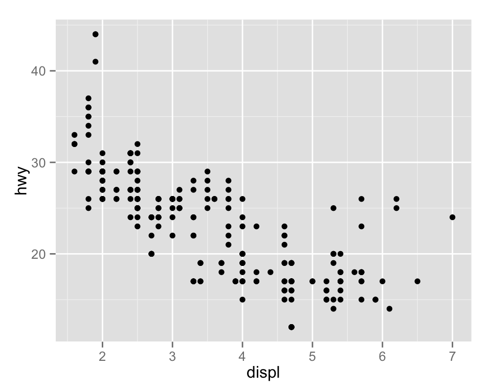

```r
ggplot(mpg, aes(x = displ, y = hwy)) +
  geom_point()
```

Podemos representar variables adicionales usando otras características estéticas (*aesthetics*) como forma, color o tamaño.

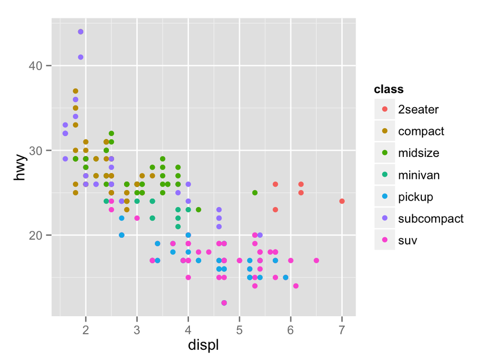

```r
ggplot(mpg, aes(x = displ, y = hwy, color = class)) +
  geom_point()
```

Experimenta con los *aesthetics* color (color), tamaño (size) y forma (shape).

¿Qué diferencia hay entre las variables categóricas y las continuas?

¿Qué ocurre cuando combinas varios *aesthetics*?

El mapeo de las propiedades estéticas depende del tipo de variable, las variables discretas (por ejemplo, genero, escolaridad, país) se mapean a distintas escalas que las variables continuas (variables numéricas como edad, estatura, etc.):

|  | Discreta | Continua |
| --- | --- | --- |
| Color | Arcoiris de colores | Gradiente de colores |
| Tamaño | Escala discreta de tamaños | Mapeo lineal entre el radio y el valor |
| Forma | Distintas formas | No aplica |

La segunda parte de la instrucción de graficar (después del símbolo +) corresponde a las geometrías, *geoms*, que controlan el tipo de gráfica

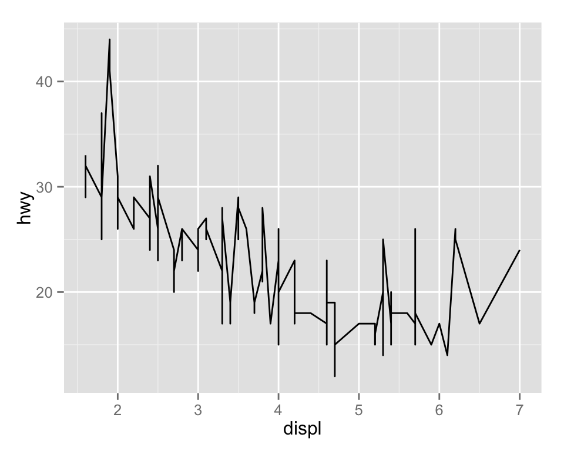

```r
p <- ggplot(mpg, aes(x = displ, y = hwy))
p + geom_line() # en este caso no es una buena gráfica
```

¿Qué problema tiene la siguiente gráfica?

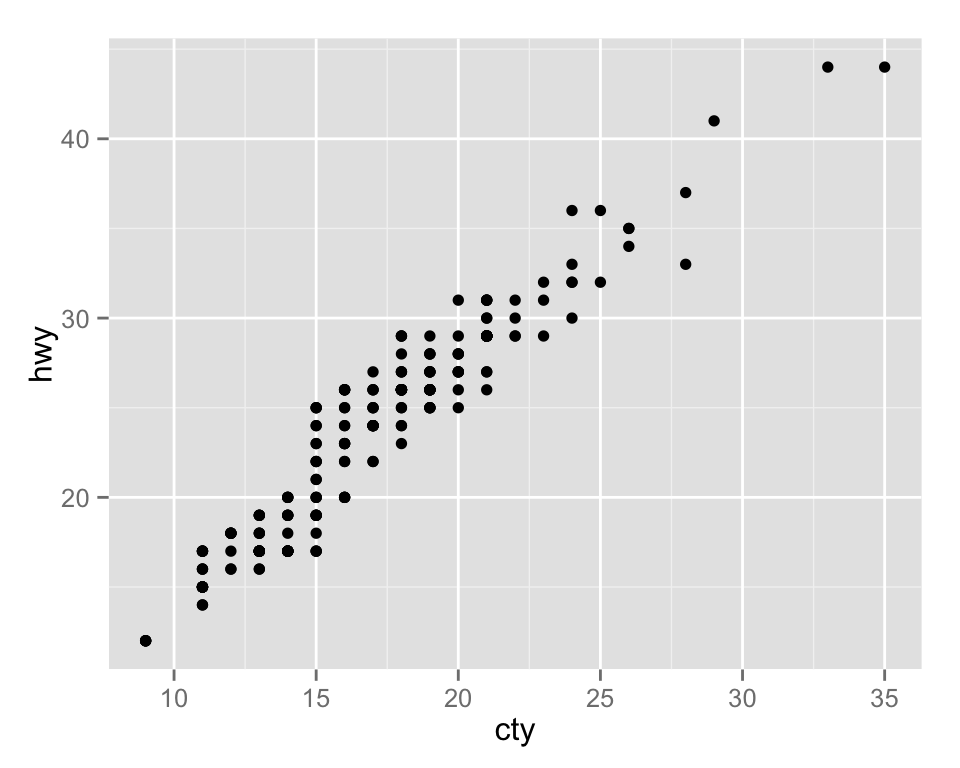

```r
p <- ggplot(mpg, aes(x = cty, y = hwy))
p + geom_point()
```

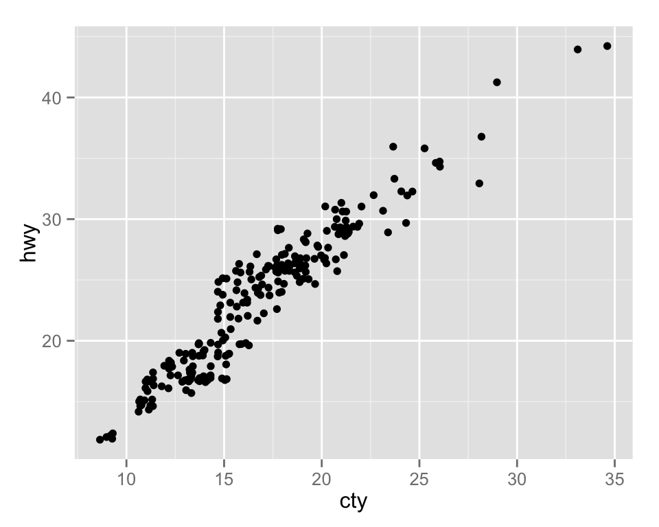

```r
p + geom_jitter()
```

¿Cómo podemos mejorar la siguiente gráfica?

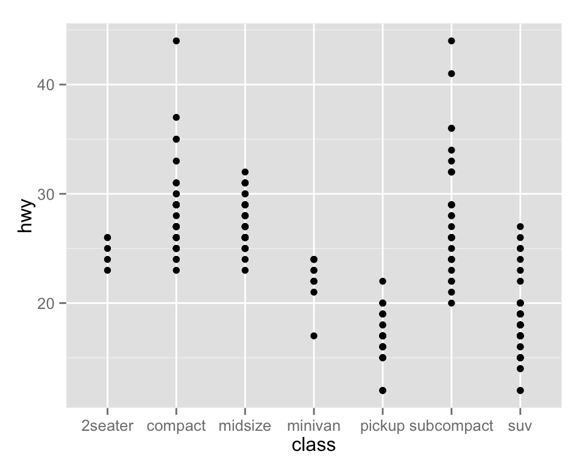

```r
ggplot(mpg, aes(x = class, y = hwy)) +
  geom_point()
```

Intentemos reodenar los niveles de la variable clase

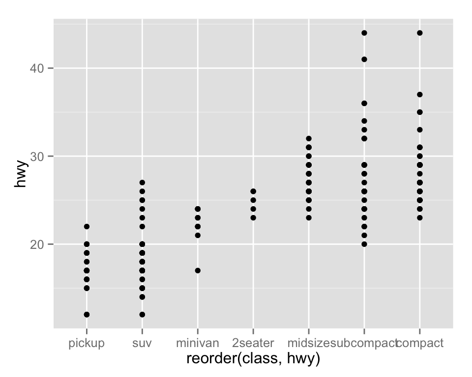

```r
ggplot(mpg, aes(x = reorder(class, hwy), y = hwy)) +
    geom_point()
```

Podemos probar otros geoms.

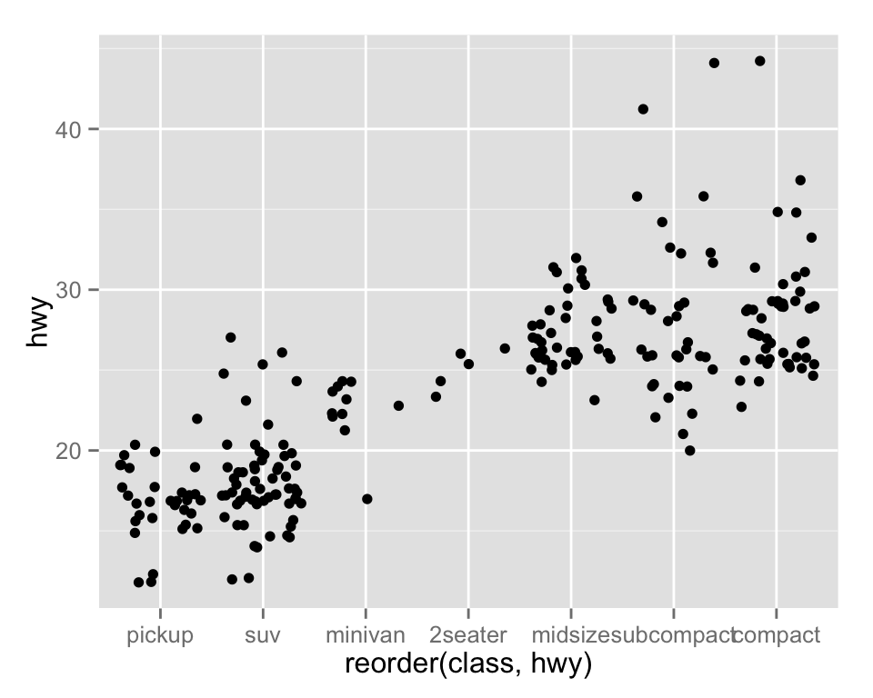

```r
ggplot(mpg, aes(x = reorder(class, hwy), y = hwy)) +
    geom_jitter()
```

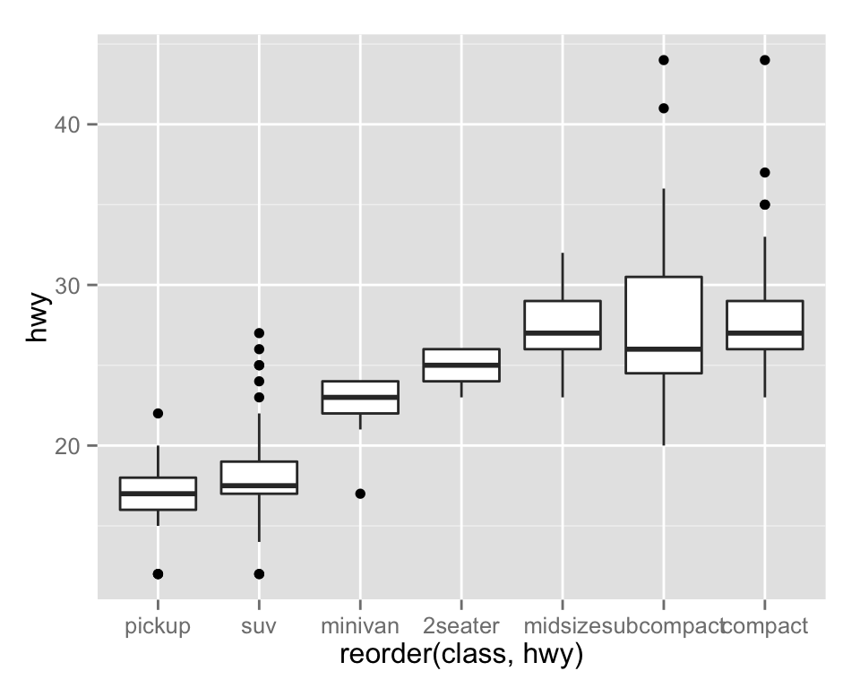

```r
ggplot(mpg, aes(x = reorder(class, hwy), y = hwy)) +
    geom_boxplot()
```

También podemos usar más de un geom!

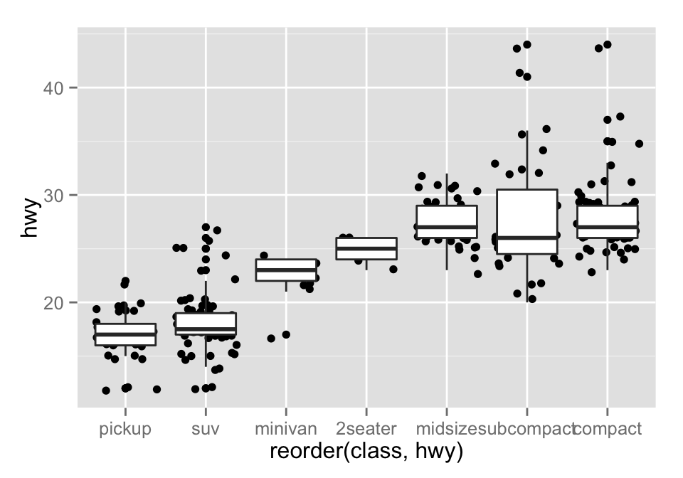

```r
ggplot(mpg, aes(x = reorder(class, hwy), y = hwy)) +
    geom_jitter() +
    geom_boxplot()
```

Lee la ayuda de *reorder* y repite las gráficas anteriores ordenando por la mediana de *hwy*.

¿Cómo harías para graficar los puntos encima de las cajas de boxplot?

#### Paneles

Veamos ahora como hacer páneles de gráficas, la idea es hacer varios múltiplos de una gráfica donde cada múltiplo representa un subconjunto de los datos, es una práctica muy útil para explorar relaciones condicionales.

En ggplot podemos usar *facet_wrap()* para hacer paneles dividiendo los datos de acuerdo a las categorías de una sola variable

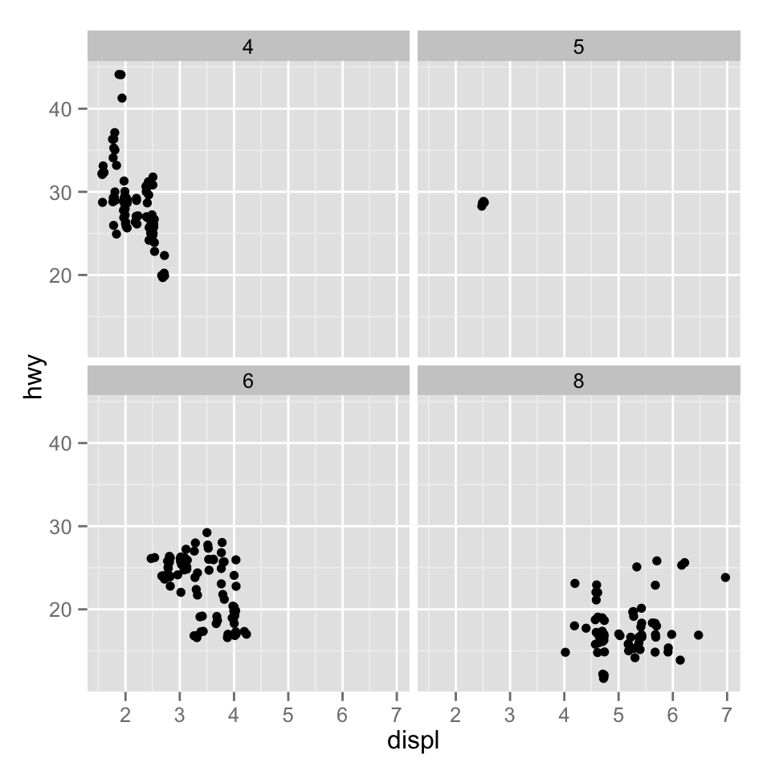

```r
ggplot(mpg, aes(x = displ, y = hwy)) +
  geom_jitter() +
  facet_wrap(~ cyl)
```

También podemos hacer una cuadrícula de 2 dimensiones usando *facet_grid(filas~columnas)*

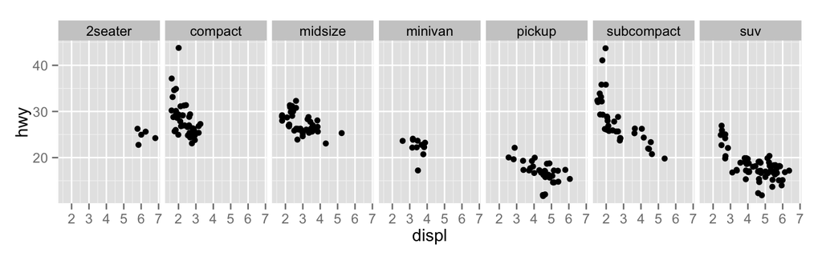

```r
ggplot(mpg, aes(x = displ, y = hwy)) +
  geom_jitter() +
  facet_grid(.~ class)
```

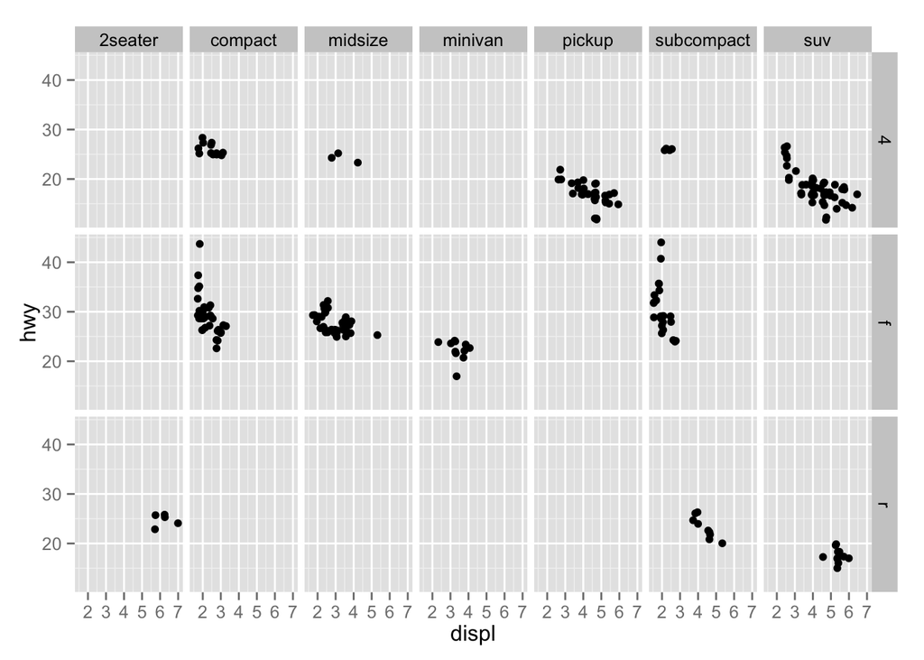

```r
ggplot(mpg, aes(x = displ, y = hwy)) +
  geom_jitter() +
  facet_grid(drv ~ class)
```

Los páneles pueden ser muy útiles para entender relaciones en nuestros datos. En la siguiente gráfica es difícil entender si existe una relación entre radiación solar y ozono:

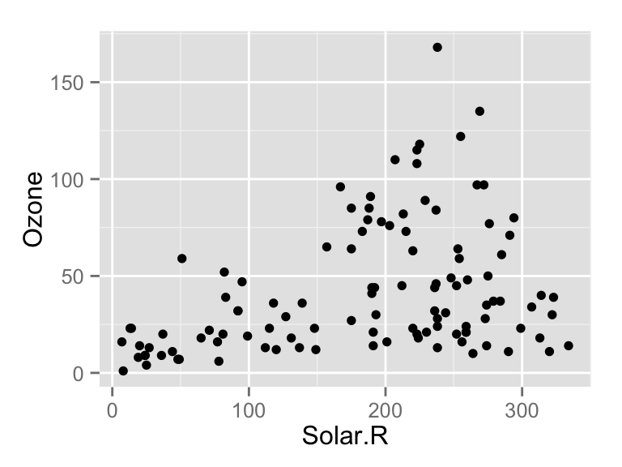

```r
data(airquality)
ggplot(airquality, aes(x = Solar.R, y = Ozone)) +
  geom_point()
```

Veamos que ocurre si realizamos páneles separando por velocidad del viento

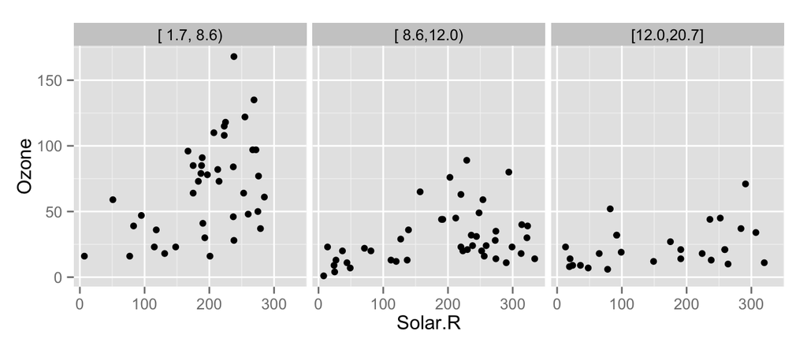

```r
library(Hmisc)
airquality$Wind.cat <- cut2(airquality$Wind, g = 3)
ggplot(airquality, aes(x = Solar.R, y = Ozone)) +
  geom_point() +
  facet_wrap(~ Wind.cat)
```

Podemos agregar un suavizador (loess) para ver mejor la relación de las variables en cada panel.

```
## geom_smooth: method="auto" and size of largest group is <1000, so using loess. Use 'method = x' to change the smoothing method.
## geom_smooth: method="auto" and size of largest group is <1000, so using loess. Use 'method = x' to change the smoothing method.
## geom_smooth: method="auto" and size of largest group is <1000, so using loess. Use 'method = x' to change the smoothing method.
```

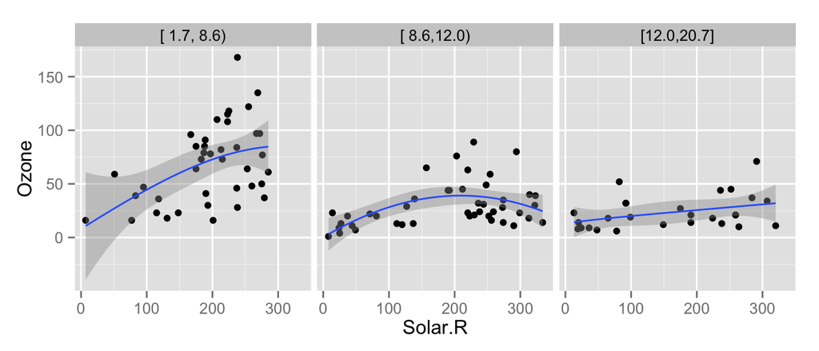

```r
ggplot(airquality, aes(x = Solar.R, y = Ozone)) +
  geom_point() +
  facet_wrap(~ Wind.cat) +
  geom_smooth(span = 3)
```

Escribe algunas preguntas que puedan contestar con estos datos.

En ocasiones es necesario realizar transformaciones u obtener subconjuntos de los datos para poder responder preguntas de nuestro interés, por ejemplo, la base de datos que cargamos al inicio de esta sección (bnames) contiene los 1000 nombres de niña y niño mas populares en EUA entre 1880 y 2008.

```r
head(bnames)
```

```
## Source: local data frame [6 x 4]
##
##    year    name  percent   sex
##   (int)   (chr)    (dbl) (chr)
## 1  1880    John 0.081541   boy
## 2  1880 William 0.080511   boy
## 3  1880   James 0.050057   boy
## 4  1880 Charles 0.045167   boy
## 5  1880  George 0.043292   boy
## 6  1880   Frank 0.027380   boy
```

Supongamos que queremos ver la tendencia del nombre “John”, para ello debemos generar un subconjunto de la base de datos.

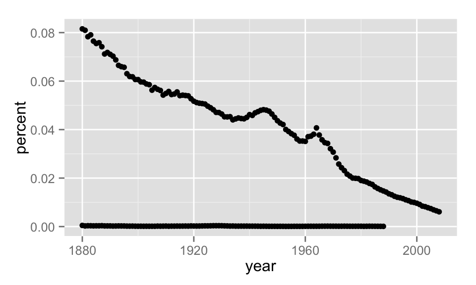

```r
bnames_John <- bnames[bnames$name == "John", ]
ggplot(bnames_John, aes(x = year, y = percent)) +
  geom_point()
```

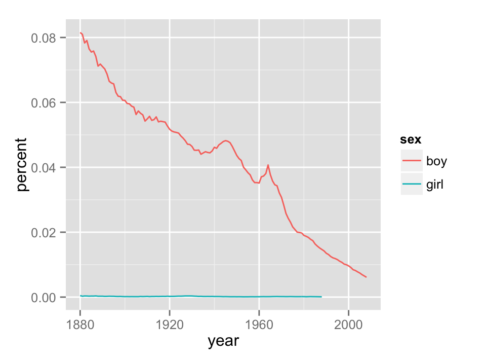

```r
ggplot(bnames_John, aes(x = year, y = percent, color = sex)) +
  geom_line()
```

La preparación de los datos es un aspecto muy importante del análisis y suele ser la fase que lleva más tiempo. Es por ello que el siguiente tema se enfocará en herramientas para hacer transformaciones de manera eficiente.

Tarea. Explora la base de datos msleep, estos datos están incluidos en el paquete ggplot2 para acceder a ellos basta con cargar el paquete:

```r
library(ggplot2)
head(msleep)
```

```
##                         name      genus  vore        order conservation
## 1                    Cheetah   Acinonyx carni    Carnivora           lc
## 2                 Owl monkey      Aotus  omni     Primates         <NA>
## 3            Mountain beaver Aplodontia herbi     Rodentia           nt
## 4 Greater short-tailed shrew    Blarina  omni Soricomorpha           lc
## 5                        Cow        Bos herbi Artiodactyla domesticated
## 6           Three-toed sloth   Bradypus herbi       Pilosa         <NA>
##   sleep_total sleep_rem sleep_cycle awake brainwt  bodywt
## 1        12.1        NA          NA  11.9      NA  50.000
## 2        17.0       1.8          NA   7.0 0.01550   0.480
## 3        14.4       2.4          NA   9.6      NA   1.350
## 4        14.9       2.3   0.1333333   9.1 0.00029   0.019
## 5         4.0       0.7   0.6666667  20.0 0.42300 600.000
## 6        14.4       2.2   0.7666667   9.6      NA   3.850
```

realiza al menos 3 gráficas y explica las relaciones que encuentres. Al menos una de las gráficas debe ser de páneles, si lo consideras interesante, puedes crear una variable categórica utilizando la función cut2 del paquete Hmisc.

### Recursos

- Buscar ayuda: Google, [StackOverflow](http://stackoverflow.com/questions/tagged/r), [seekR](http://seekr.international). Para aprender más sobre un paquete o una función pueden visitar [Rdocumentation.org](http://www.rdocumentation.org/).
- Para aprender los comandos básicos de R [*Try R*](http://tryr.codeschool.com/) y [Datacamp](https://www.datacamp.com/) cuentan con excelentes cursos interactivos.
- Referencia de bolsillo a principales comandos de R: [R Reference Card](https://cran.r-project.org/doc/contrib/Short-refcard.pdf)
- Para aprender programación avanzada en R, el libro gratuito [Advanced R](http://adv-r.had.co.nz) de Hadley Wickham es una buena referencia. En particular es conveniente leer la [guía de estilo](http://adv-r.had.co.nz/Style.html) (para todos: principiantes, intermedios y avanzados).
- Para mantenerse al tanto de las noticias de la comunidad de R pueden visitar [R-bloggers](http://www.r-bloggers.com).
- Para entretenerse en una tarde domingo pueden navegar los reportes en [RPubs](https://rpubs.com).
- [Lista de paquetes y recursos](https://github.com/qinwf/awesome-R#integrated-development-environment)
- Para aprender más de ggplot pueden ver la documentación con ejemplos en la página de [ggplot2](http://docs.ggplot2.org/current/).
- Otro recurso muy útil es el [acordeón de ggplot](https://www.rstudio.com/wp-content/uploads/2015/04/ggplot2-spanish.pdf).